# R Notebook

### Project Material-Dialogs

```r
#Importing functions:
source("~/R/software-history/scripts/utils.R")
project <- "Material-Dialogs"
#Csv's:
results_frame <-
  read.csv(
    paste0("/home/r4ph/R/analysis/results/",project,"_resultsRqsBugsIns.csv"),
    stringsAsFactors = FALSE
  )
methods_insertions <-
  read.csv(
    paste0("~/R/analysis/results_insertions/",project,"_insertionTs.csv"),
    stringsAsFactors = FALSE
  )
methods_total<-
  read.csv(
    paste0("~/R/analysis/results/",project,"_changesTsWithBugsIns.csv"),
    stringsAsFactors = FALSE
  )
results_frame$Project <- project
```

### Raw Dataset:

Aqui é apresentado o dataset que foi discutido na ultima reunião conforme planilha que o Biel gerou no Google Drive. Tal dataset consiste na relação entre os valores de mudanças e inserção de bugs commit. Segue uma descrição das respectivas colunas:

**NoCommits** : A Quantidade de commits (k) que a time serie possui;

**commit** : O respectivo commit dentro da time series com k commits;

**NoTimeSeries** : Quantidade de time series no commit;

**NoBugsIns** : Quantidade de bugs inseridos no respectivo commit;

**noChanges** : Quantidade de mudanças;

**percBugs** : Percentual de bugs inseridos [Formula noBugsIns/sum(noBugsIns)];

**percChanges** : Percentual de mudanças [Formula: noChanges/sum(noChanges) ];

```r
results_frame
```

| X | Project | NoCommits | commit | noTimeSeries | noBugsIns | noChanges | percBugs | percChanges |
| --- | --- | --- | --- | --- | --- | --- | --- | --- |
| 1 | Material-Dialogs | 1 | 1 | 7 | 3 | 138 | 1.000000000 | 1.0000000000 |
| 2 | Material-Dialogs | 2 | 1 | 377 | 650 | 10212 | 0.637880275 | 0.4903956973 |
| 3 | Material-Dialogs | 2 | 2 | 377 | 369 | 10612 | 0.362119725 | 0.5096043027 |
| 4 | Material-Dialogs | 3 | 1 | 334 | 937 | 9191 | 0.692023634 | 0.3232738912 |
| 5 | Material-Dialogs | 3 | 2 | 334 | 173 | 9457 | 0.127769572 | 0.3326298758 |
| 6 | Material-Dialogs | 3 | 3 | 334 | 244 | 9783 | 0.180206795 | 0.3440962330 |
| 7 | Material-Dialogs | 4 | 1 | 125 | 115 | 3335 | 0.271867612 | 0.2258719946 |
| 8 | Material-Dialogs | 4 | 2 | 125 | 138 | 3712 | 0.326241135 | 0.2514053505 |
| 9 | Material-Dialogs | 4 | 3 | 125 | 64 | 3505 | 0.151300236 | 0.2373857094 |
| 10 | Material-Dialogs | 4 | 4 | 125 | 106 | 4213 | 0.250591017 | 0.2853369455 |

[output cut: 990 more lines]

### Final Dataset:

Aqui é apresentado o dataset com as metricas calculadas com o objetivo de gerar os respectivos gráficos presentes na Goal 1 e 2. Segue uma descrição das colunas e suas respectivas formulas:

**NoCommits** : A Quantidade de commits (k) que a time serie possui;

**NoTimeSeries** : Quantidade de time series no commit;

**noChanges** : Quantidade de mudanças;

**NoBugsIns** : Quantidade de bugs inseridos no respectivo commit;

**BugsByTs** : Quantidade de bugs por time series [Formula : sum(noBugsIns)/max(noTimeSeries) ];

**ChangesByTs**: Quantidade de mudanças pro time series [Formula: sum(noChanges)/ max(noTimeSeries)];

**PercBugsByTs**: Percentual de bugs por time series [Formula: (BugsByTs/sum(BugsByTs)) * 100];

**PercBugsByCommit**: Percentual de Bugs por commits [Formula: (noBugsIns/sum(noBugsIns)) * 100];

**PercBugsByChanges**: Percentual de Bugs por mudanças [Formula: (BugsByChanges/sum(BugsByChanges)) * 100];

**PercTs**: Percentual de time series [Formula: noTimeSeries / sum(noTimeSeries)) * 100];

**PercChangesByTs**: Percentual de mudanças por time series [Formula: (ChangesByTs / sum(ChangesByTs)) * 100];

**PercChanges**: Percentual de mudanças [Formula: (noChanges / sum(noChanges)) * 100];

Obs: Conforme explicado, os dados anteriores (raw dataset) tem algumas colunas desnormalizadas (NoTimeSeries), portanto algumas formulas contém o valor maximo da respectiva coluna dentro do agrupamento definido.

```r
#Final Data Frame
data_plot <- as.data.frame(
  results_frame %>%
    dplyr::group_by(Project, NoCommits) %>%
    dplyr::summarise(
      noTimeSeries = max(noTimeSeries),
      noChanges = sum(noChanges),
      noBugsIns = sum(noBugsIns),
      BugsByTs = sum(noBugsIns) / max(noTimeSeries),
      BugsByChanges = sum(noBugsIns) / sum(noChanges),
      ChangesByTs = sum(noChanges) / max(noTimeSeries)
    ) %>%
    dplyr::mutate(
      PercBugsByTs = (BugsByTs / sum(BugsByTs)) * 100,
      PercBugsByCommit = (noBugsIns / sum(noBugsIns)) * 100,
      PercBugsByChanges = (BugsByChanges / sum(BugsByChanges)) * 100,
      PercTs = (noTimeSeries / sum(noTimeSeries)) * 100,
      PercChangesByTs = (ChangesByTs / sum(ChangesByTs)) * 100,
      PercChanges = (noChanges / sum(noChanges)) * 100
    ) %>%
    dplyr::ungroup()
)
data_plot
```

| Project | NoCommits | noTimeSeries | noChanges | noBugsIns | BugsByTs | BugsByChanges | ChangesByTs | PercBugsByTs | PercBugsByCommit | PercBugsByChanges | PercTs | PercChangesByTs | PercChanges |
| --- | --- | --- | --- | --- | --- | --- | --- | --- | --- | --- | --- | --- | --- |
| Material-Dialogs | 1 | 7 | 138 | 3 | 0.4285714 | 0.021739130 | 19.71429 | 0.04095333 | 0.03617945 | 2.2743769 | 0.5109489 | 0.03129777 | 0.04808899 |
| Material-Dialogs | 2 | 377 | 20824 | 1019 | 2.7029178 | 0.048933922 | 55.23607 | 0.25828481 | 12.28895321 | 5.1195323 | 27.5182482 | 0.08769103 | 7.25655822 |
| Material-Dialogs | 3 | 334 | 28431 | 1354 | 4.0538922 | 0.047624072 | 85.12275 | 0.38738092 | 16.32899180 | 4.9824941 | 24.3795620 | 0.13513817 | 9.90737643 |
| Material-Dialogs | 4 | 125 | 14765 | 423 | 3.3840000 | 0.028648832 | 118.12000 | 0.32336751 | 5.10130246 | 2.9972790 | 9.1240876 | 0.18752354 | 5.14517298 |
| Material-Dialogs | 5 | 84 | 13336 | 404 | 4.8095238 | 0.030293941 | 158.76190 | 0.45958739 | 4.87216594 | 3.1693926 | 6.1313869 | 0.25204534 | 4.64720805 |
| Material-Dialogs | 6 | 92 | 19489 | 445 | 4.8369565 | 0.022833393 | 211.83696 | 0.46220880 | 5.36661843 | 2.3888601 | 6.7153285 | 0.33630560 | 6.79134956 |
| Material-Dialogs | 7 | 77 | 16271 | 740 | 9.6103896 | 0.045479688 | 211.31169 | 0.91834744 | 8.92426435 | 4.7581457 | 5.6204380 | 0.33547170 | 5.66997017 |
| Material-Dialogs | 8 | 52 | 13364 | 443 | 8.5192308 | 0.033148758 | 257.00000 | 0.81407873 | 5.34249879 | 3.4680673 | 3.7956204 | 0.40800500 | 4.65696524 |
| Material-Dialogs | 9 | 49 | 16815 | 589 | 12.0204082 | 0.035028249 | 343.16327 | 1.14864345 | 7.10323203 | 3.6647022 | 3.5766423 | 0.54479505 | 5.85953835 |
| Material-Dialogs | 10 | 31 | 10348 | 235 | 7.5806452 | 0.022709702 | 333.80645 | 0.72438958 | 2.83405692 | 2.3759194 | 2.2627737 | 0.52994048 | 3.60597697 |

[output cut: 30 more lines]

### (G1)To investigate the occurrence of commits along the time series;

#### (Q1.1) How often are commits performed along the time series?

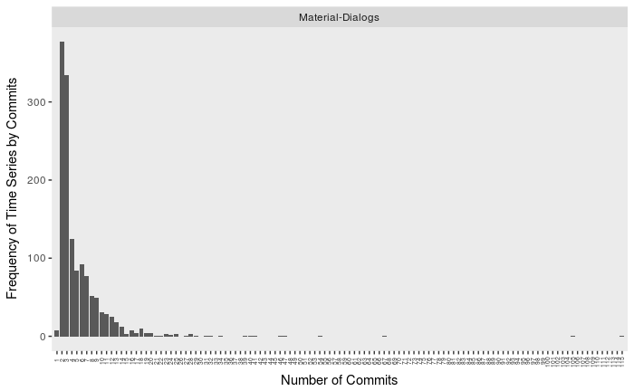

```r
#Frequency:
ggplot(data_plot) +
  geom_bar(aes(x=NoCommits,y=noTimeSeries,group=Project), position = "dodge", stat = "identity") +
  facet_grid(.~Project,scales="free") +
  theme(legend.position= c(0.7, 0.95), legend.direction="horizontal", legend.title = element_blank(),
        legend.text=element_text(size=5), legend.background = element_rect(fill = "transparent", colour = NA) ) +
  ylab("Frequency of Time Series by Commits") + scale_x_discrete(name ="Number of Commits", limits=seq(1,max(data_plot$NoCommits))) +
  theme(panel.grid.minor = element_blank(),
        panel.grid.major = element_blank(),
        plot.background = element_rect(fill = "transparent", colour = NA),
        axis.text.x = element_text(colour="grey20",size=5,angle=90,hjust=.5,vjust=.5,face="plain"))
```

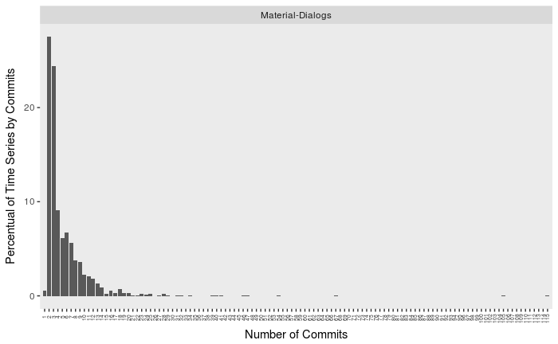

```r
#Percentual
ggplot(data_plot) +
  geom_bar(aes(x=NoCommits,y=PercTs,group=Project), position = "dodge", stat = "identity")+
  facet_grid(.~Project,scales="free") +
  theme(legend.position= c(0.7, 0.95), legend.direction="horizontal", legend.title = element_blank(),
        legend.text=element_text(size=5), legend.background = element_rect(fill = "transparent", colour = NA) ) +
  ylab("Percentual of Time Series by Commits") + scale_x_discrete(name ="Number of Commits", limits=seq(1,max(data_plot$NoCommits))) +
  theme(panel.grid.minor = element_blank(),
        panel.grid.major = element_blank(),
        plot.background = element_rect(fill = "transparent", colour = NA),
        axis.text.x = element_text(colour="grey20",size=5,angle=90,hjust=.5,vjust=.5,face="plain"))
```

#### (Q1.2) How often are changes performed among commits?

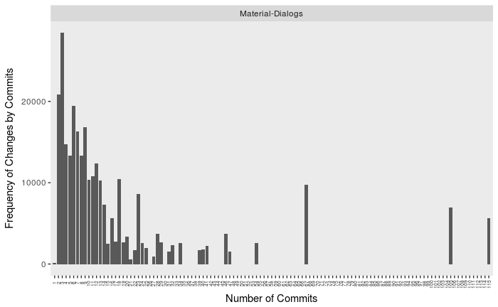

```r
#Frequency:
ggplot(data_plot) +
  geom_bar(aes(x=NoCommits,y=noChanges), position = "dodge", stat = "identity")+
  facet_grid(.~Project,scales="free") +
  theme(legend.position= c(0.7, 0.95), legend.direction="horizontal", legend.title = element_blank(),
        legend.text=element_text(size=5), legend.background = element_rect(fill = "transparent", colour = NA)) +
  ylab("Frequency of Changes by Commits") + scale_x_discrete(name ="Number of Commits", limits=seq(1,max(data_plot$NoCommits))) +
  theme(panel.grid.minor = element_blank(),
        panel.grid.major = element_blank(),
        plot.background = element_rect(fill = "transparent", colour = NA),
        axis.text.x = element_text(colour="grey20",size=5,angle=90,hjust=.5,vjust=.5,face="plain"))
```

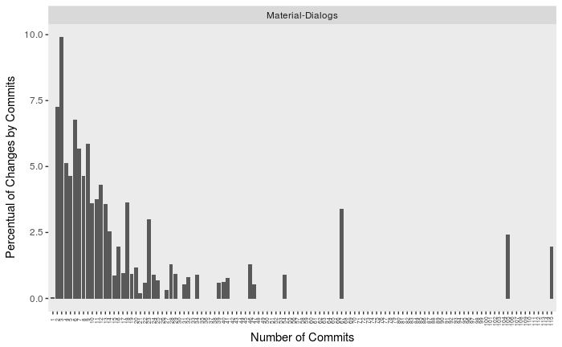

```r
#Percentual
ggplot(data_plot) +
  geom_bar(aes(x=NoCommits,y=PercChanges), position = "dodge", stat = "identity")+
  facet_grid(.~Project,scales="free") +
  theme(legend.position= c(0.7, 0.95), legend.direction="horizontal", legend.title = element_blank(),
        legend.text=element_text(size=5), legend.background = element_rect(fill = "transparent", colour = NA)) +
  ylab("Percentual of Changes by Commits") + scale_x_discrete(name ="Number of Commits", limits=seq(1,max(data_plot$NoCommits))) +
  theme(panel.grid.minor = element_blank(),
        panel.grid.major = element_blank(),
        plot.background = element_rect(fill = "transparent", colour = NA),
        axis.text.x = element_text(colour="grey20",size=5,angle=90,hjust=.5,vjust=.5,face="plain"))
```

#### (Q1.3) How often are changes performed among time series?

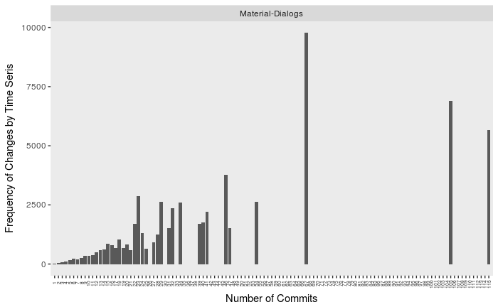

```r
#Frequency:
ggplot(data_plot) +
  geom_bar(aes(x=NoCommits,y=ChangesByTs), position = "dodge", stat = "identity")+
  facet_grid(.~Project,scales="free") +
  theme(legend.position= c(0.7, 0.95), legend.direction="horizontal", legend.title = element_blank(),
        legend.text=element_text(size=5), legend.background = element_rect(fill = "transparent", colour = NA)) +
  ylab("Frequency of Changes by Time Seris") + scale_x_discrete(name ="Number of Commits", limits=seq(1,max(data_plot$NoCommits))) +
  theme(panel.grid.minor = element_blank(),
        panel.grid.major = element_blank(),
        plot.background = element_rect(fill = "transparent", colour = NA),
        axis.text.x = element_text(colour="grey20",size=5,angle=90,hjust=.5,vjust=.5,face="plain"))
```

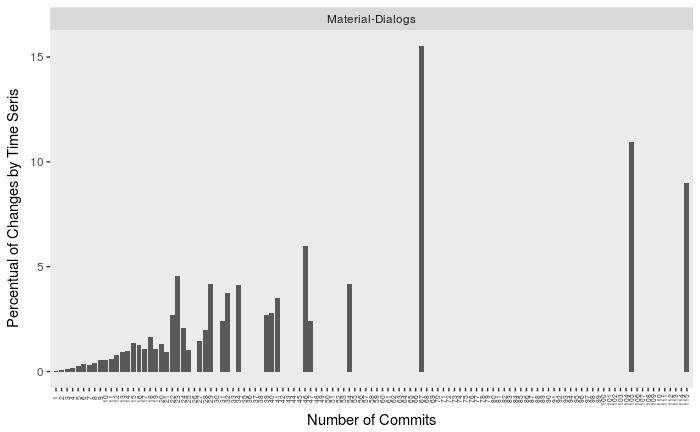

```r
#Percentual:
ggplot(data_plot) +
  geom_bar(aes(x=NoCommits,y=PercChangesByTs), position = "dodge", stat = "identity")+
  facet_grid(.~Project,scales="free") +
  theme(legend.position= c(0.7, 0.95), legend.direction="horizontal", legend.title = element_blank(),
        legend.text=element_text(size=5), legend.background = element_rect(fill = "transparent", colour = NA)) +
  ylab("Percentual of Changes by Time Seris") + scale_x_discrete(name ="Number of Commits", limits=seq(1,max(data_plot$NoCommits))) +
  theme(panel.grid.minor = element_blank(),
        panel.grid.major = element_blank(),
        plot.background = element_rect(fill = "transparent", colour = NA),
        axis.text.x = element_text(colour="grey20",size=5,angle=90,hjust=.5,vjust=.5,face="plain"))
```

### (G2)To assess the introduction of bugs along the history;

#### (Q2.1) How often are bugs introduced among the commits?

[figure not shown]

```r
#Freq:
ggplot(data_plot) +
  geom_bar(aes(x=NoCommits,y=noBugsIns), position = "dodge", stat = "identity")+
  facet_grid(.~Project,scales="free") +
  theme(legend.position= c(0.7, 0.95), legend.direction="horizontal", legend.title = element_blank(),
        legend.text=element_text(size=5), legend.background = element_rect(fill = "transparent", colour = NA)) +
  ylab("Percentual of Bugs by Commits") + scale_x_discrete(name ="Number of Commits", limits=seq(1,max(data_plot$NoCommits))) +
  theme(panel.grid.minor = element_blank(),
        panel.grid.major = element_blank(),
        plot.background = element_rect(fill = "transparent", colour = NA),
        axis.text.x = element_text(colour="grey20",size=5,angle=90,hjust=.5,vjust=.5,face="plain"))
```

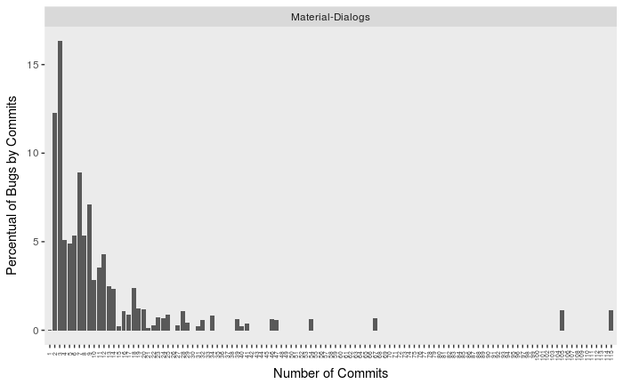

```r
#Perc
ggplot(data_plot) +
  geom_bar(aes(x=NoCommits,y=PercBugsByCommit), position = "dodge", stat = "identity")+
  facet_grid(.~Project,scales="free") +
  theme(legend.position= c(0.7, 0.95), legend.direction="horizontal", legend.title = element_blank(),
        legend.text=element_text(size=5), legend.background = element_rect(fill = "transparent", colour = NA)) +
  ylab("Percentual of Bugs by Commits") + scale_x_discrete(name ="Number of Commits", limits=seq(1,max(data_plot$NoCommits))) +
  theme(panel.grid.minor = element_blank(),
        panel.grid.major = element_blank(),
        plot.background = element_rect(fill = "transparent", colour = NA),
        axis.text.x = element_text(colour="grey20",size=5,angle=90,hjust=.5,vjust=.5,face="plain"))
```

#### (Q2.2) How often are bugs introduced among the time series?

[figure not shown]

```r
#Frequency:
ggplot(data_plot) +
  geom_bar(aes(x=NoCommits,y=BugsByTs), position = "dodge", stat = "identity")+
  facet_grid(.~Project,scales="free") +
  theme(legend.position= c(0.7, 0.95), legend.direction="horizontal", legend.title = element_blank(),
        legend.text=element_text(size=5), legend.background = element_rect(fill = "transparent", colour = NA)) +
  ylab("Percentual of Bugs by Time Series") + scale_x_discrete(name ="Number of Commits", limits=seq(1,max(data_plot$NoCommits))) +
  theme(panel.grid.minor = element_blank(),
        panel.grid.major = element_blank(),
        plot.background = element_rect(fill = "transparent", colour = NA),
        axis.text.x = element_text(colour="grey20",size=5,angle=90,hjust=.5,vjust=.5,face="plain"))
```

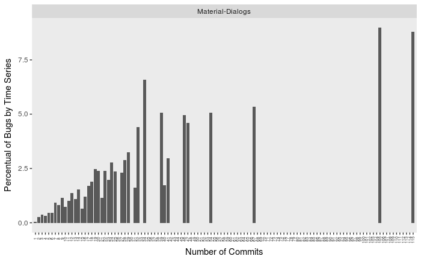

```r
#Percentual:
ggplot(data_plot) +
  geom_bar(aes(x=NoCommits,y=PercBugsByTs), position = "dodge", stat = "identity")+
  facet_grid(.~Project,scales="free") +
  theme(legend.position= c(0.7, 0.95), legend.direction="horizontal", legend.title = element_blank(),
        legend.text=element_text(size=5), legend.background = element_rect(fill = "transparent", colour = NA)) +
  ylab("Percentual of Bugs by Time Series") + scale_x_discrete(name ="Number of Commits", limits=seq(1,max(data_plot$NoCommits))) +
  theme(panel.grid.minor = element_blank(),
        panel.grid.major = element_blank(),
        plot.background = element_rect(fill = "transparent", colour = NA),
        axis.text.x = element_text(colour="grey20",size=5,angle=90,hjust=.5,vjust=.5,face="plain"))
```

#### (Q2.3) How often are bugs introduced among the changes?

[figure not shown]

```r
#Freq:
ggplot(data_plot) +
  geom_bar(aes(x=NoCommits,y=BugsByChanges), position = "dodge", stat = "identity")+
  facet_grid(.~Project,scales="free") +
  theme(legend.position= c(0.7, 0.95), legend.direction="horizontal", legend.title = element_blank(),
        legend.text=element_text(size=5), legend.background = element_rect(fill = "transparent", colour = NA)) +
  ylab("Percentual of Bugs by Changes") + scale_x_discrete(name ="Number of Commits", limits=seq(1,max(data_plot$NoCommits))) +
  theme(panel.grid.minor = element_blank(),
        panel.grid.major = element_blank(),
        plot.background = element_rect(fill = "transparent", colour = NA),
        axis.text.x = element_text(colour="grey20",size=5,angle=90,hjust=.5,vjust=.5,face="plain"))
```

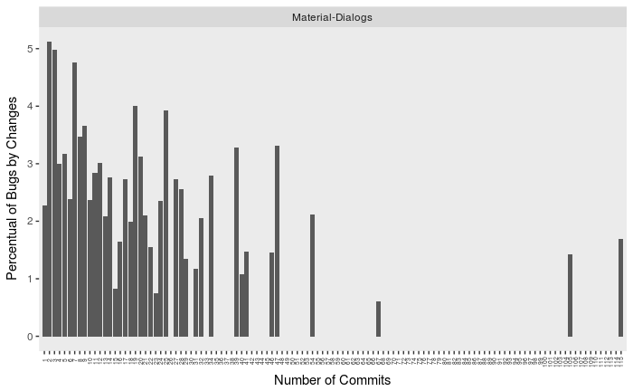

```r
#Perc:
ggplot(data_plot) +
  geom_bar(aes(x=NoCommits,y=PercBugsByChanges), position = "dodge", stat = "identity")+
  facet_grid(.~Project,scales="free") +
  theme(legend.position= c(0.7, 0.95), legend.direction="horizontal", legend.title = element_blank(),
        legend.text=element_text(size=5), legend.background = element_rect(fill = "transparent", colour = NA)) +
  ylab("Percentual of Bugs by Changes") + scale_x_discrete(name ="Number of Commits", limits=seq(1,max(data_plot$NoCommits))) +
  theme(panel.grid.minor = element_blank(),
        panel.grid.major = element_blank(),
        plot.background = element_rect(fill = "transparent", colour = NA),
        axis.text.x = element_text(colour="grey20",size=5,angle=90,hjust=.5,vjust=.5,face="plain"))
```

### (G3) To analyse the kind of changes are mostly related to the bugs insertion;

#### (Q3.1) Which are the types (Add/Del) of changes more frequent in the bugs insertion?

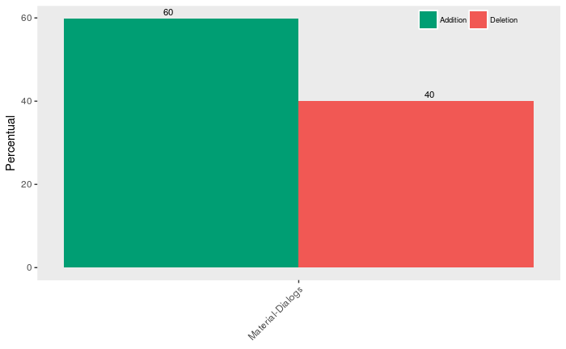

```r
#Changes Chart
methods_changes <- filter(methods_insertions, changeType != 'All', groupMetric == 'All', Metric == 'All')
methods_changes[methods_changes$changeType == "changeMetricsAddition", c("changeType")] <- "Addition"
methods_changes[methods_changes$changeType == "changeMetricsDeletion", c("changeType")] <- "Deletion"
cbPalette <- c("#009E73", "#F15854")
methods_changes <-  as.data.frame(
  methods_changes %>%
    dplyr::group_by(Project, changeType) %>%
    dplyr::summarise(totalChanges = sum(Count)) %>%
    mutate(Percentual = totalChanges / sum(totalChanges) * 100) %>%
    ungroup()
)
ggplot(methods_changes) +
  geom_bar(aes(x = Project, y = Percentual, fill = changeType, group = changeType), position = "dodge", stat = "identity") +
  geom_text( aes(x = Project, y = Percentual, label = round(Percentual), group = changeType),
             check_overlap = TRUE, position = position_dodge(width = 1), vjust = -0.5, size = 3) + #scale_fill_grey() +
  theme(axis.text.x = element_text(angle = 45, hjust = 1)) +
  theme(legend.position= c(0.82, 0.95), legend.direction="horizontal", legend.title = element_blank(),
        axis.title.x=element_blank(), legend.text=element_text(size=7), legend.background = element_rect(fill = "transparent", colour = NA) ) +
  theme(panel.grid.minor = element_blank(),
        panel.grid.major = element_blank(),
        plot.background = element_rect(fill = "transparent", colour = NA)) +
  scale_fill_manual(values=cbPalette)
```

#### (Q3.2) Which are the metrics groups more frequent in the bugs insertion?

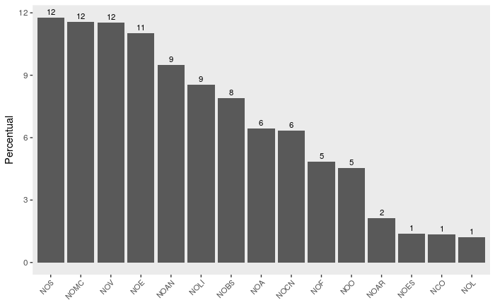

```r
#Filter:D
methods_groups<- filter(methods_insertions, groupMetric != "RM", changeType == 'All', groupMetric != 'All', Metric == 'All')
#Group measures
methods_groups <-  as.data.frame(
  methods_groups %>%
    dplyr::group_by(Project, groupMetric) %>%
    dplyr::summarise(Changes = sum(Count)) %>%
    dplyr::mutate(Percentual = Changes / sum(Changes) * 100) %>%
    dplyr::ungroup()
)
#Plot
  ggplot(methods_groups) +
    geom_bar(aes(x = reorder(groupMetric, -Percentual), y = Percentual), position = "dodge", stat = "identity") +
    geom_text( aes(x = reorder(groupMetric, -Percentual), y = Percentual, label = round(Percentual)),
               check_overlap = TRUE, position = position_dodge(width = 1), vjust = -0.5, size = 3) + #scale_fill_grey() +
    theme(axis.text.x = element_text(angle = 45, hjust = 1, size= 8)) +
    theme(legend.position= c(0.82, 0.95), legend.direction="horizontal", legend.title = element_blank(),
          axis.title.x=element_blank(), legend.text=element_text(size=7), legend.background = element_rect(fill = "transparent", colour = NA) ) +
    theme(panel.grid.minor = element_blank(),
          panel.grid.major = element_blank(),
          plot.background = element_rect(fill = "transparent", colour = NA))
```

#### (Q3.3) Which are the change metrics more frequent in the bugs insertion?

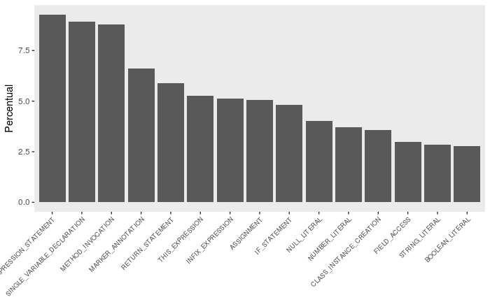

```r
#Filter:D
methods_ind <- filter(methods_insertions, groupMetric != "RM", changeType == 'All', groupMetric != 'All', Metric != 'All')
#ORder metrics by frequency
freqs_metrics <- plyr::count(methods_ind$Metric)
freqs_metrics <- freqs_metrics[order(-freqs_metrics$freq), ]
#Grouping data
methods_ind <-  as.data.frame(
  methods_ind %>%
    dplyr::group_by(Project, Metric) %>%
    dplyr::summarise(Changes = sum(Count)) %>%
    dplyr::mutate(Percentual = Changes / sum(Changes) * 100) %>%
    dplyr::ungroup()
)
#Top metrics
top_metrics <- head(freqs_metrics, 15)
methods_ind <- methods_ind[methods_ind$Metric %in% top_metrics$x, ]
#Plot
ggplot(methods_ind) +
  geom_bar(aes(x = reorder(Metric, -Percentual), y = Percentual), position = "dodge", stat = "identity") +
  #geom_text( aes(x = reorder(Metric, -Percentual), y = Percentual, label = round(Percentual)),
  #          check_overlap = TRUE, position = position_dodge(width = 1), vjust = -0.5, size = 3) + #scale_fill_grey() +
  theme(axis.text.x = element_text(angle = 45, hjust = 1, size = 7)) +
  theme(legend.position= c(0.82, 0.95), legend.direction="horizontal", legend.title = element_blank(),
        axis.title.x=element_blank(), legend.text=element_text(size=7), legend.background = element_rect(fill = "transparent", colour = NA) ) +
  theme(panel.grid.minor = element_blank(),
        panel.grid.major = element_blank(),
        plot.background = element_rect(fill = "transparent", colour = NA))
```

### (G4) To analyse the relation between the history of changes and bugs;

#### (Q4.1) Is a high number of changes an indicative of bugs introduction?

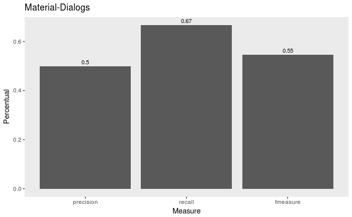

```r
#Changes Chart
methods_changes <- filter(methods_total, changeType == 'All', groupMetric == 'All', Metric == 'All')
#Calculing peaks
methods_changes[,"totalofBugsIns"] <-   maply(methods_changes$bugsInsertion, getTotalBugsIns)
#Filtering only ts with bugs and more with one commit
methods_changes <- filter(methods_changes, totalofBugsIns > 0, NtimeofCommits > 1)
#Generating id of data frame
methods_changes <- genId(methods_changes)
#List of changes and bugs insertions
listofPeaks <<- methods_changes$elementsValue
listofBugsIns <<- methods_changes$bugsInsertion
#Creating columns
methods_changes[,c("peaks", "tp", "fp", "fn", "tn", "precision", "recall", "fmeasure")] <- 0
#calculating confusion matrix
methods_changes[,c("peaks", "tp", "fp", "fn", "tn", "precision", "recall", "fmeasure")]  <-  plyr::ldply(methods_changes$id, getStatsProcess)
#Grouping data
confusion_matrix <- as.data.frame(
  methods_changes %>%
    dplyr::group_by(Project) %>%
    dplyr::summarise(
      precision = median(precision, na.rm = TRUE),
      recall = median(recall, na.rm = TRUE),
      fmeasure = median(fmeasure, na.rm = TRUE)
    )
)
#Pivot data
confusion_matrix <- melt(dfPeaks, id = (c("Project")))
colnames(confusion_matrix) <- c("Project", "Measure", "Values")
#Ploting results
ggplot(confusion_matrix) +
  geom_bar(aes(x = Measure, y = Values), position = "dodge", stat = "identity") +
  geom_text(aes(x = Measure, y = Values, label = round(Values,2)),
            check_overlap = TRUE, position = position_dodge(width = 1), vjust = -0.5, size = 3) +
  theme(legend.direction="vertical", legend.title = element_blank(), legend.text=element_text(size=8),
        legend.background = element_rect(fill = "transparent", colour = NA), axis.ticks.x = ) +
  theme(panel.grid.minor = element_blank(),
        panel.grid.major = element_blank(),
        plot.background = element_rect(fill = "transparent", colour = NA)) +
  ggtitle(project) + ylab("Percentual")
```